# PS #03

Author

Boyuan Ma

[Link to GitHub](https://github.com/mab0y/Stats-506/tree/main/PS-03)

I have provided hyperlinks to all pertinent resources and references that assisted me in addressing this problem.

## Problem 1 - Vision

### a.

Import the `DEMO_D.XPT` file and save the data to a new file named `DEMO_D.dta`:

```stata
. cd C:\Users\mab0y\OneDrive\文档\Stats-506\PS-03
C:\Users\mab0y\OneDrive\文档\Stats-506\PS-03

. import sasxport5 DEMO_D.XPT

. save DEMO_D
file DEMO_D.dta saved
```

Import the `VIX_D.XPT` file from the provided link. Utilize the [merge command](https://www.stata.com/manuals/dmerge.pdf) to combine it with the `DEMO_D` dataset. Upon completion of this step, generate a new database named `MERGED` ensuring it encompasses a total of 6,980 rows.

```stata
. import sasxport5 VIX_D.XPT

. merge 1:1 seqn using DEMO_D, keep(match)

    Result                      Number of obs
    -----------------------------------------
    Not matched                             0
    Matched                             6,980  (_merge==3)
    -----------------------------------------

. save MERGED
file MERGED.dta saved

. count
  6,980
```

### b.

Create a new variable named `viq220_1`. Exclude any entries with `Don't know` and `Missing` values. Next, transform `viq220_1` into dummy variables, assigning a value of 1 for `Yes` and 0 for `No`:

```stata
. gen viq220_1 = .
(6,980 missing values generated)

. replace viq220_1 = 0 if viq220 == 2
(3,780 real changes made)

. replace viq220_1 = 1 if viq220 == 1
(2,765 real changes made)
```

Classify respondents based on their age in 10-year increments. To achieve this, I utilized the [floor function](https://www.statalist.org/forums/forum/general-stata-discussion/general/1367450-rounding-down-every-output-to-integral-numbers) to round ages down to the nearest decade. Then I employed a loop to generate this age-based classification:

```stata
. gen ridageyr_1 = floor(ridageyr/10)*10

. gen ridageyr_1_class = "Not Available"

. foreach i of numlist 0/9 {
  2.         local start = 10*`i'
  3.         local end = 10*`i'+9
  4.         replace ridageyr_1_class = "`start'-`end'" if ridageyr_1 == `i'*10
  5. }
(0 real changes made)
(2,207 real changes made)
(1,021 real changes made)
(818 real changes made)
(815 real changes made)
(631 real changes made)
(661 real changes made)
(469 real changes made)
(358 real changes made)
(0 real changes made)
```

Utilize the collapse function to generate the table:

```stata
. preserve

. collapse (mean) viq220_1, by(ridageyr_1_class)

. list

     +---------------------+
     | ridage~s   viq220_1 |
     |---------------------|
  1. |    10-19   .3208812 |
  2. |    20-29   .3265742 |
  3. |    30-39   .3586667 |
  4. |    40-49   .3699871 |
  5. |    50-59   .5500821 |
     |---------------------|
  6. |    60-69   .6222222 |
  7. |    70-79   .6689038 |
  8. |    80-89   .6688103 |
     +---------------------+

. restore
```

### c.

Create dummy variables derived from the `ridreth1`:

```stata
. gen mexican_american_dummy = (ridreth1 == 1)

. gen other_hispanic_dummy = (ridreth1 == 2)

. gen non_hispanic_white_dummy = (ridreth1 == 3)

. gen non_hispanic_black_dummy = (ridreth1 == 4)
```

Create a new variable named `riagendr_1` by converting the `riagendr` into dummy variables. Assign the labels `female` and `male` to these variables:

```stata
. gen riagendr_1 = (riagendr==1)

. label define sex 0 "female" 1 "male"

. label values riagendr_1 sex
```

Fit three separate logistic logistic regression:

```stata
. logit viq220_1 ridageyr, or

Iteration 0:   log likelihood = -4457.6265
Iteration 1:   log likelihood = -4236.2351
Iteration 2:   log likelihood = -4235.9433
Iteration 3:   log likelihood = -4235.9433

Logistic regression                                     Number of obs =  6,545
                                                        LR chi2(1)    = 443.37
                                                        Prob > chi2   = 0.0000
Log likelihood = -4235.9433                             Pseudo R2     = 0.0497

------------------------------------------------------------------------------
    viq220_1 | Odds ratio   Std. err.      z    P>|z|     [95% conf. interval]
-------------+----------------------------------------------------------------
    ridageyr |    1.02498   .0012356    20.47   0.000     1.022561    1.027405
       _cons |    .283379   .0151461   -23.59   0.000     .2551952    .3146755
------------------------------------------------------------------------------
Note: _cons estimates baseline odds.

. estimates store model1

.
. logit viq220_1 ridageyr mexican_american_dummy other_hispanic_dummy non_hispanic_white_dummy non_h
> ispanic_black_dummy riagendr_1 , or

Iteration 0:   log likelihood = -4457.6265
Iteration 1:   log likelihood = -4138.3859
Iteration 2:   log likelihood = -4136.8807
Iteration 3:   log likelihood = -4136.8805

Logistic regression                                     Number of obs =  6,545
                                                        LR chi2(6)    = 641.49
                                                        Prob > chi2   = 0.0000
Log likelihood = -4136.8805                             Pseudo R2     = 0.0720

------------------------------------------------------------------------------------------
                viq220_1 | Odds ratio   Std. err.      z    P>|z|     [95% conf. interval]
-------------------------+----------------------------------------------------------------
                ridageyr |   1.022831   .0012912    17.88   0.000     1.020303    1.025365
  mexican_american_dummy |   .5215282   .0706186    -4.81   0.000     .3999623    .6800432
    other_hispanic_dummy |   .6097722   .1203815    -2.51   0.012     .4141169    .8978675
non_hispanic_white_dummy |   1.018101   .1324116     0.14   0.890     .7890156    1.313699
non_hispanic_black_dummy |   .6776529    .090558    -2.91   0.004     .5215034     .880557
              riagendr_1 |   .6052646   .0320857    -9.47   0.000     .5455346    .6715345
                   _cons |   .5048045   .0661152    -5.22   0.000     .3905168    .6525393
------------------------------------------------------------------------------------------
Note: _cons estimates baseline odds.

. estimates store model2

.
. logit viq220_1 ridageyr mexican_american_dummy other_hispanic_dummy non_hispanic_white_dummy non_h
> ispanic_black_dummy riagendr_1 indfmpir, or

Iteration 0:   log likelihood = -4259.5533
Iteration 1:   log likelihood = -3948.3256
Iteration 2:   log likelihood = -3946.9043
Iteration 3:   log likelihood = -3946.9041

Logistic regression                                     Number of obs =  6,247
                                                        LR chi2(7)    = 625.30
                                                        Prob > chi2   = 0.0000
Log likelihood = -3946.9041                             Pseudo R2     = 0.0734

------------------------------------------------------------------------------------------
                viq220_1 | Odds ratio   Std. err.      z    P>|z|     [95% conf. interval]
-------------------------+----------------------------------------------------------------
                ridageyr |   1.022436    .001324    17.14   0.000     1.019845    1.025035
  mexican_american_dummy |    .587002   .0822693    -3.80   0.000     .4460076    .7725683
    other_hispanic_dummy |   .6592157   .1333587    -2.06   0.039     .4434353     .979997
non_hispanic_white_dummy |   .9692835   .1294291    -0.23   0.815     .7460866    1.259251
non_hispanic_black_dummy |   .7222799   .0991681    -2.37   0.018     .5518698    .9453104
              riagendr_1 |   .5967415    .032406    -9.51   0.000     .5364902    .6637595
                indfmpir |   1.120301   .0198376     6.42   0.000     1.082087    1.159865
                   _cons |   .3801607   .0543067    -6.77   0.000     .2873237    .5029942
------------------------------------------------------------------------------------------
Note: _cons estimates baseline odds.

. estimates store model3
```

Here is the [summary table](https://stats.oarc.ucla.edu/stata/faq/how-can-i-use-estout-to-make-regression-tables-that-look-like-those-in-journal-articles/) presenting the estimation results:

```
. estout model1 model2 model3, cells(b(star fmt(3)) se(par fmt(2))) eform stats(N r2_p aic,fmt(0 3 3
> ))

------------------------------------------------------------
                   model1          model2          model3
                     b/se            b/se            b/se
------------------------------------------------------------
viq220_1
ridageyr            1.025***        1.023***        1.022***
                   (0.00)          (0.00)          (0.00)
mexican_am~y                        0.522***        0.587***
                                   (0.07)          (0.08)
other_hisp~y                        0.610*          0.659*
                                   (0.12)          (0.13)
non_~e_dummy                        1.018           0.969
                                   (0.13)          (0.13)
non_~k_dummy                        0.678**         0.722*
                                   (0.09)          (0.10)
riagendr_1                          0.605***        0.597***
                                   (0.03)          (0.03)
indfmpir                                            1.120***
                                                   (0.02)
_cons               0.283***        0.505***        0.380***
                   (0.02)          (0.07)          (0.05)
------------------------------------------------------------
N                    6545            6545            6247
r2_p                0.050           0.072           0.073
aic              8475.887        8287.761        7909.808
------------------------------------------------------------
```

### d.

In both the second and third logistic regression models, the variable `riagendr_1` is statistically significant at the 1% confidence level. This suggests a significant difference in the odds of men and women wearing glasses or contact lenses for distance vision.

Employ the [two-sample z-test](https://www.ssc.wisc.edu/sscc/pubs/sfs/sfs-prtest.htm) to determine if there’s a significant difference in the proportion of men and women who wear glasses or contact lenses for distance vision:

```stata
. prtest viq220_1, by(riagendr_1)

Two-sample test of proportions                female: Number of obs =     3350
                                                male: Number of obs =     3195
------------------------------------------------------------------------------
       Group |       Mean   Std. err.      z    P>|z|     [95% conf. interval]
-------------+----------------------------------------------------------------
      female |   .4728358   .0086259                      .4559293    .4897423
        male |   .3696401   .0085398                      .3529023    .3863778
-------------+----------------------------------------------------------------
        diff |   .1031958   .0121382                      .0794054    .1269861
             |  under H0:   .0122146     8.45   0.000
------------------------------------------------------------------------------
        diff = prop(female) - prop(male)                          z =   8.4485
    H0: diff = 0

    Ha: diff < 0                 Ha: diff != 0                 Ha: diff > 0
 Pr(Z < z) = 1.0000         Pr(|Z| > |z|) = 0.0000          Pr(Z > z) = 0.0000
```

The difference and the standard error were calculated under the null hypothesis to obtain the Z-statistic. With a p-value of 0.0000, we reject the null hypothesis. This indicates a significant difference in the proportion of men and women who wear glasses or contact lenses for distance vision.

## Problem 2 - Sakila

### a.

All films are in English:

```r
dbGetQuery(sakila,"SELECT l.name, COUNT(f.film_id) FROM film f JOIN language l ON f.language_id = l.language_id GROUP BY l.name")
```

```
     name COUNT(f.film_id)
1 English             1000
```

### b.

Extract `film_category` and `category`:

```r
film_category<-dbGetQuery(sakila,"SELECT * FROM film_category")
category<-dbGetQuery(sakila,"SELECT * FROM category")
```

`film_id` and `category_id` maintain a one-to-one relationship. To determine the most prevalent genre, it’s essential to sort the table by each `category_id` and match the respective `category_name`. The data reveals that `Sports` is the most predominant genre, comprising 74 movies.”:

```r
max_category_id<-sort(table(film_category$category_id),decreasing = TRUE)
max_category_name<-cbind(category$name[as.numeric(names(max_category_id))],as.vector(max_category_id))
```

```
      [,1]          [,2]
 [1,] "Sports"      "74"
 [2,] "Foreign"     "73"
 [3,] "Family"      "69"
 [4,] "Documentary" "68"
 [5,] "Animation"   "66"
 [6,] "Action"      "64"
 [7,] "New"         "63"
 [8,] "Drama"       "62"
 [9,] "Games"       "61"
[10,] "Sci-Fi"      "61"
[11,] "Children"    "60"
[12,] "Comedy"      "58"
[13,] "Classics"    "57"
[14,] "Travel"      "57"
[15,] "Horror"      "56"
[16,] "Music"       "51"
```

Use SQL query to get the same result:

```r
dbGetQuery(sakila, "SELECT c.name,COUNT(fc.film_id) as number FROM film_category fc JOIN category c ON fc.category_id = c.category_id GROUP BY c.name ORDER BY number DESC")
```

```
          name number
1       Sports     74
2      Foreign     73
3       Family     69
4  Documentary     68
5    Animation     66
6       Action     64
7          New     63
8        Drama     62
9       Sci-Fi     61
10       Games     61
11    Children     60
12      Comedy     58
13      Travel     57
14    Classics     57
15      Horror     56
16       Music     51
```

### c.

Extract `customer`, `address`, `city` and `country`:

```r
customer<-dbGetQuery(sakila,"SELECT * FROM customer")
address<-dbGetQuery(sakila,"SELECT * FROM address")
city<-dbGetQuery(sakila,"SELECT * FROM city")
country<-dbGetQuery(sakila,"SELECT * FROM country")
```

I utilized [`merge`](https://www.statmethods.net/management/merging.html) to merge these four data_frames together on their foreign keys:

```r
cust_address<-merge(customer,address,by="address_id")
cust_address_city<-merge(cust_address,city,by="city_id")
cust_address_city_country<-merge(cust_address_city,country,by="country_id")
```

United Kingdom have exactly 9 customers:

```r
country_table<-table(cust_address_city_country$country)
country_name <- country_table[country_table == 9]
```

```
United Kingdom
             9
```

Use SQL query to get the same result:

```r
dbGetQuery(sakila, "SELECT country.country,COUNT(cust.customer_id) as number FROM customer cust JOIN address a ON cust.address_id=a.address_id JOIN city ON a.city_id=city.city_id JOIN country ON city.country_id=country.country_id GROUP BY country.country HAVING number=9")
```

```
         country number
1 United Kingdom      9
```

## Problem 3 - US Records

### a.

14% of email addresses are hosted at a domain with TLD “.net”:

```r
length(grep("\\.net$", us_500$email))/length(us_500$email)
```

```
[1] 0.14
```

### b.

50.6% of email addresses have at least one non alphanumeric character in them:

```r
length(grep("[^a-zA-Z0-9]+[a-zA-Z0-9]*@", us_500$email))/length(us_500$email)
```

```
[1] 0.506
```

### c.

973 is the most common area code amongst all phone numbers:

```r
area_code<-table(sapply(us_500$phone1,substr,start=1,stop=3))
area_code_most_common<-area_code[which.max(area_code)]
```

```
973
 18
```

### d.

Strip away the portion of the string preceding the apartment numbers, replacing it with an empty string to get the apartment number:

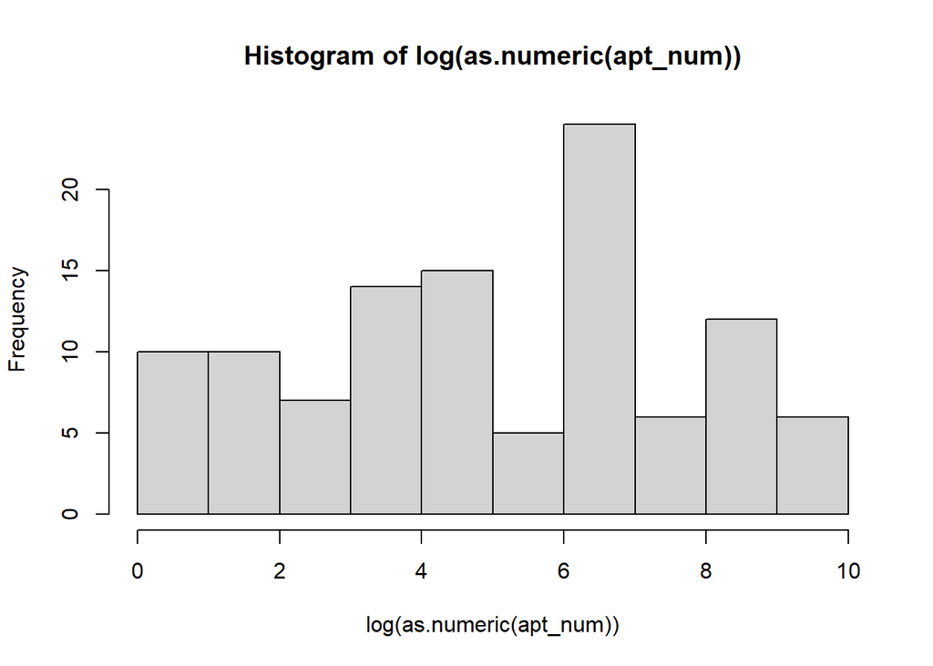

```r
address_apt<-us_500$address[grep(".+#", us_500$address)]
apt_num<-gsub(pattern=".+#", replacement = "", address_apt)
hist(log(as.numeric(apt_num)))
```

### e.

Extract the leading digit from the apartment numbers and represent the distribution using a bar chart. Based on the visual representation, the apartment numbers do not seem to conform to Benford’s Law, implying that these numbers might not be indicative of genuine data:

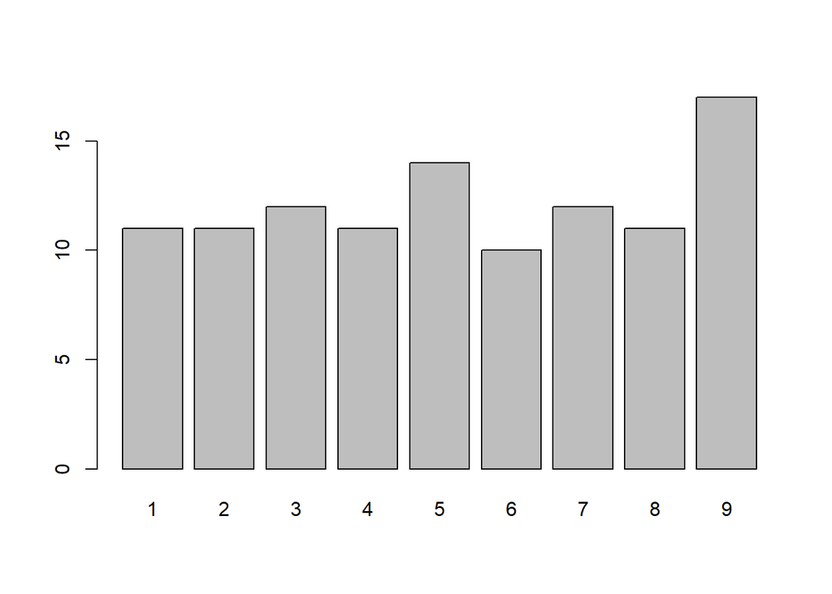

```r
apt_num_leading<-as.numeric(substr(apt_num,1,1))
barplot(table(apt_num_leading))
```

The probability distribution observed in the real data markedly deviates from the expected distribution according to Benford’s Law:

```r
apt_num_leading_dist<-table(apt_num_leading)/length(apt_num_leading)
benford<-log(1+1/c(1:9),base=10)
names(benford)<-1:9

cbind(apt_num_leading_dist,benford)
```

```
  apt_num_leading_dist    benford
1           0.10091743 0.30103000
2           0.10091743 0.17609126
3           0.11009174 0.12493874
4           0.10091743 0.09691001
5           0.12844037 0.07918125
6           0.09174312 0.06694679
7           0.11009174 0.05799195
8           0.10091743 0.05115252
9           0.15596330 0.04575749
```

### f.

Split the address string at spaces and retrieve the initial segment (representing the street number). Convert this segment into a numeric format by calculating the modulus of the numeric value by 10 to determine its last digit:

```r
st_split<-strsplit(us_500$address," ")
st_num <- as.numeric(sapply(st_split, function(x) x[1]))
st_num_last<-st_num %%10
st_num_last<-st_num_last[st_num_last>0]
```

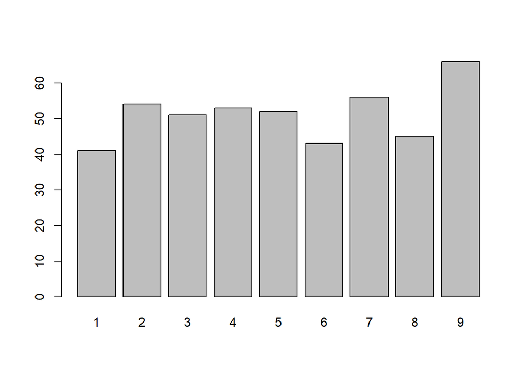

```r
barplot(table(st_num_last))
```

The distribution observed in the data deviates from what’s anticipated under Benford’s Law:

```r
st_num_last_dist<-table(st_num_last)/length(st_num_last)
cbind(st_num_last_dist,benford)
```

```
  st_num_last_dist    benford
1       0.08893709 0.30103000
2       0.11713666 0.17609126
3       0.11062907 0.12493874
4       0.11496746 0.09691001
5       0.11279826 0.07918125
6       0.09327549 0.06694679
7       0.12147505 0.05799195
8       0.09761388 0.05115252
9       0.14316703 0.04575749
```